# Week 3 - Differential expression

Gareth Gillard, Lars Grønvold, Niklas Mähler, Torgeir R. Hvidsten

Last change: 14.09.2024

## Introduction

In this lab we are going to run differential expression tests on the RNA-Seq data from the [Voineagu et al](http://www.nature.com/nature/journal/v474/n7351/full/nature10110.html) autistic brain study. We will detect genes with differential expression between the autistic and control brain samples.

**OBS**: Some parts of this exercise is a tutorial where you only have to copy and run the code. Don’t be content with that: try to understand what the code does! In the R Markdown report, only include code and results that are needed to document what you are asked to produce yourself (in red). Also remember to answer all questions in red.

First we will look at a constructed example of how to detect differential expression with only a single gene.

## Single gene example data

Imagine we want to investigate if a specific gene is expressed at a different level in individuals that have a specific disease compared to healthy control individuals. To test this, we have measured the expression of the gene in 20 individuals, 10 with the disease and 10 controls. For this example we will just simulate the expression values by generating some random numbers:

```r
# Generate 10 random numbers around a mean of 8 for control and 10 for disease, with standard deviation of 1
exprControl <- rnorm(10, mean=8, sd=1)
exprDisease <- rnorm(10, mean=10, sd=1)
```

Instead of having the data in two separate vectors we want to have it as a single expression vector as this is how we usually receive the data:

```r
# Join the two vectors of numbers together
expr <- c(exprControl, exprDisease)
```

To know which samples are control samples and which are disease samples we need another vector that contains this information about the samples (this is sometimes referred to as sample metadata or phenotype). The vector must be of the same length as the expression vector since each element corresponds to each sample. It is common to use a factor vector for this kind of data:

```r
# Repeat "control" 10 times and "disease" 10 times
condition <- rep(factor(c("control","disease")), each=10)
```

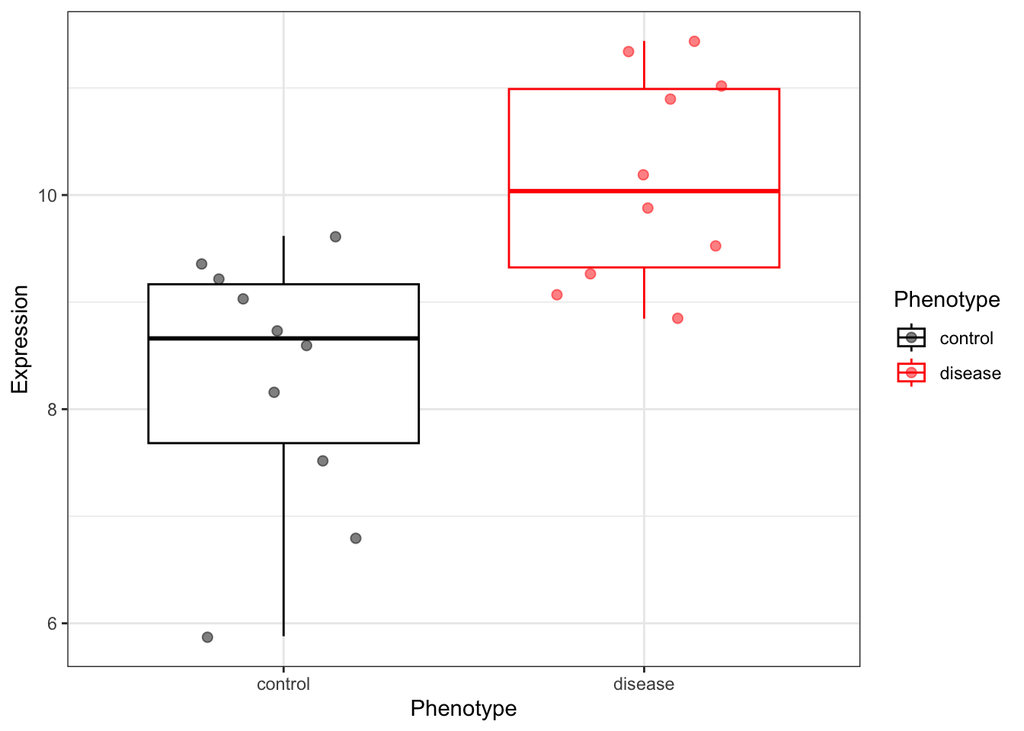

```r
tibble(Expression = expr, Phenotype = condition) %>%
  ggplot(aes(x = Phenotype, y = Expression, col = Phenotype)) +
  geom_boxplot() +
  geom_jitter(size = 2, alpha = 0.5, width = 0.25) +
  scale_color_manual(values=c("black", "red")) +
  theme_bw() # I hate that default grey background
```

### T-test

When we test if there is a difference in expression between the control and disease samples. What we actually test is if there is a significant difference in the mean expression values for each condition. One way to do this is to perform a two sample t-test:

```r
# T-test between disease data and control data
t.test(exprDisease, exprControl,  var.equal=T)
```

```
    Two Sample t-test

data:  exprDisease and exprControl
t = 3.8, df = 18, p-value = 0.001
alternative hypothesis: true difference in means is not equal to 0
95 percent confidence interval:
 0.8207 2.8884
sample estimates:
mean of x mean of y
   10.144     8.289
```

The important output of the t-test is the p-value. If it is low enough (e.g. p<0.05) we say that the gene is differentially expressed between the conditions.

> Side note: The difference in expression is often given as the **fold change** (FC), the ratio of expression in one condition over the other, and often shown on a log2 scale. Being on a log2 scale means that decreases in expression (FC between 0 and 1) become negative (e.g. if the mean expression in the disease samples is half of that in the control samples we get a FC of 0.5 FC and log2 FC of -1) and increases in expression become positive (e.g. doubled expression gives a FC of 2 and a log2 FC of 1), and no change in expression becomes zero (FC of 1 and log2 FC of 0). This is convenient when displaying FC values.

Lets calculate the difference in sample means as FC and log2 FC:

```r
# Fold change difference in mean expression levels
FC <- mean(exprDisease) / mean(exprControl)
FC
```

```
[1] 1.224
```

```r
# Fold change difference in mean expression levels
log2FC <- log2(FC)
log2FC
```

```
[1] 0.2913
```

Positive log2 FC shows increased expression in disease samples compared to control samples. To convert back to FC, calculate 2 to the power of the log2 FC: `2^log2FC`.

### Linear models

Although you can use a t-test to test for differential expression, it is more common to use linear based models as this offers more flexibility. In standard R you have the `lm()` function to fit a simple linear model:

```r
fit <- lm(expr ~ condition)
summary(fit)
```

```
Call:
lm(formula = expr ~ condition)

Residuals:
   Min     1Q Median     3Q    Max
-2.410 -0.797  0.177  0.890  1.329

Coefficients:
                 Estimate Std. Error t value Pr(>|t|)
(Intercept)         8.289      0.348   23.82  4.6e-15 ***
conditiondisease    1.855      0.492    3.77   0.0014 **
---
Signif. codes:  0 '***' 0.001 '**' 0.01 '*' 0.05 '.' 0.1 ' ' 1

Residual standard error: 1.1 on 18 degrees of freedom
Multiple R-squared:  0.441, Adjusted R-squared:  0.41
F-statistic: 14.2 on 1 and 18 DF,  p-value: 0.00141
```

In the summary of the fitted model we can see that there are two coefficients (named `(Intercept)` and `conditiondisease`). We can recognize several of the numbers here from the t-test: The first coefficient estimate is equal to the mean of the control samples. The second coefficient estimate is equal to the difference between sample means. The t-value and p-palue of the second coefficient is equal to that of the t-test.

Let’s consider what `lm(expr ~ condition)` does. The only parameter we gave was the formula `expr ~ condition`. This tells the `lm()` function that `expr` is the response variable which depends on the predictor variable `condition`. The model can be written as:
$$y_i=\beta_1+\beta_2x_i+\varepsilon_i$$
where $i$ is the sample number, $y_i$ is `expr[i]`, $\beta_1$ and $\beta_2$ are the estimated coefficients and $\varepsilon_i$ are the residuals. $x_i$ corresponds to `condition[i]` but since `condition` is a factor with two levels (either `control` or `disease`), the `lm()` function will convert $x_i$ to either 1 or 0, where `control`=0 or `disease`=1.

We can plot the regression like this:

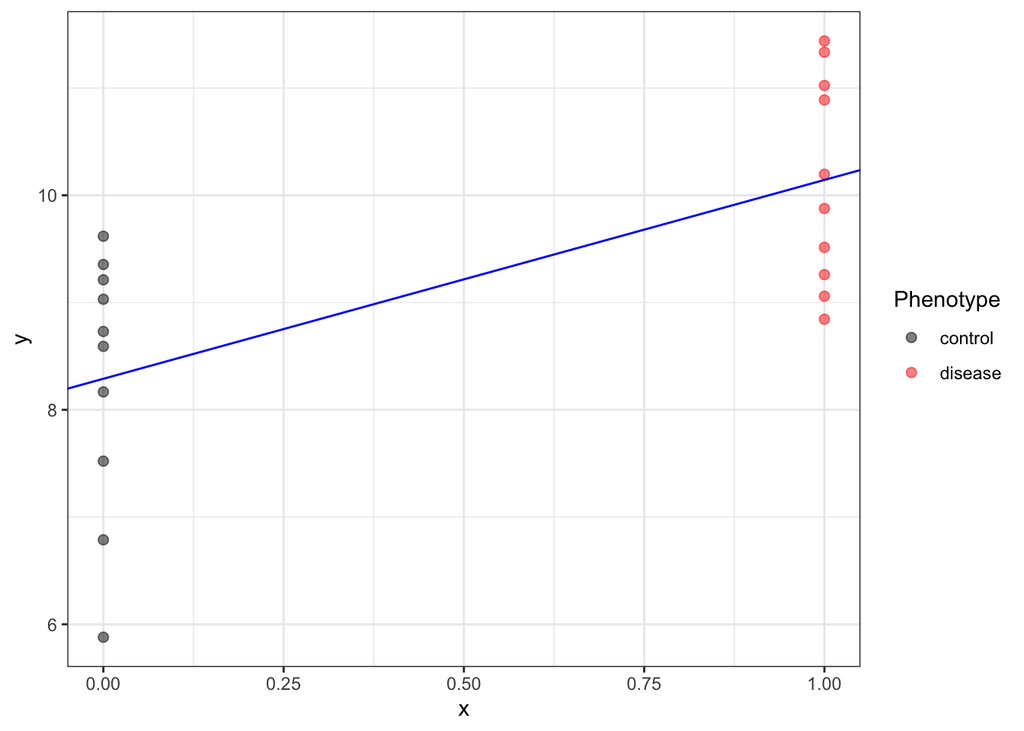

```r
beta <- fit$coefficients

tibble(y = expr, Phenotype = condition) %>%
  mutate(x = ifelse(Phenotype=="disease", 1, 0)) %>%
  ggplot(aes(x = x, y = y, col = Phenotype)) +
  geom_point(size = 2, alpha = 0.5) +
  scale_color_manual(values=c("black", "red")) +
  geom_abline(intercept = beta[1], slope = beta[2], col="blue") +
  theme_bw()
```

The `geom_abline()` function draws a straight line defined by $y=a+bx$ which corresponds to our fitted model $y=\beta_1+\beta_2x$. Notice that $\beta_2$ is the slope of the regression line and that there will only be a slope if there is difference in the expression between the control and disease samples.

We can also interpret $\beta_1$ as the baseline expression in healthy individuals and $\beta_2$ as the added expression we get in the disease condition.

### The model matrix

The model:
$$y_i=\beta_1+\beta_2x_i+\varepsilon_i$$
can also be written in matrix form:
$$\mathbf{y}=\mathbf{X}\mathbf{\beta}+\mathbf{\varepsilon}$$
where:
$$\mathbf{y}=\begin{bmatrix}y_1\\ y_2
\\ \vdots \\ y_n\end{bmatrix},
\mathbf{X}=\begin{bmatrix}1 & x_1\\ 1 & x_2 \\ \vdots &
\vdots \\ 1 &
x_n\end{bmatrix},\mathbf{\beta}=\begin{bmatrix}\beta_1\\
\beta_2\end{bmatrix},
\mathbf{\varepsilon}=\begin{bmatrix}\varepsilon_1\\ \varepsilon_2 \\
\vdots \\ \varepsilon_n\end{bmatrix}$$

The $\mathbf{X}$ matrix is called the model matrix or design matrix. We can get the model matrix from the fitted model with the `model.matrix()` function:

```r
model.matrix(fit)
```

```
   (Intercept) conditiondisease
1            1                0
2            1                0
3            1                0
4            1                0
5            1                0
6            1                0
7            1                0
8            1                0
9            1                0
10           1                0
11           1                1
12           1                1
13           1                1
14           1                1
15           1                1
16           1                1
17           1                1
18           1                1
19           1                1
20           1                1
attr(,"assign")
[1] 0 1
attr(,"contrasts")
attr(,"contrasts")$condition
[1] "contr.treatment"
```

In the model matrix the column for the condition factor is either 0 for healthy or 1 for disease.

## Autistic brain

In the Voineagu et al. study they sampled and measured the gene expression from three different brain regions (the [cerebellum](http://en.wikipedia.org/wiki/Cerebellum), [frontal cortex](http://en.wikipedia.org/wiki/Frontal_lobe) and [temporal cortex](http://en.wikipedia.org/wiki/Temporal_lobe)) from several individuals diagnosed with autism and several control individuals without autism. As a part of their study they look for differential expression between autistic brains and controls, and between brain regions. Using the RNA-seq data they have made public, we will try to replicate the results they got when looking for differential expression between autistic brains and controls in the cortex.

### The data

In the study of Voineagu et al., they performed an RNA-Seq analysis. Here, the RNA-Seq reads were aligned to the reference genome using [STAR](http://bioinformatics.oxfordjournals.org/content/29/1/15) and the number of reads overlapping each gene were counted using the `htseq-count` program from [HTSeq](https://htseq.readthedocs.io/en/master/).

The results from `htseq-count` are stored in *htseq.zip*. Download this file from Canvas and unzip it.

Modify the code you were given in Week 2 to read the data into a matrix named `counts` with gene names as row names and sample names as column names.

**OBS**: The text files have two columns, the first column contains gene names and the second column contains the number of reads that mapped to that gene.

- Note that the file has no header. Hint: Use the `col_names`-argument in the `read_tsv()`-function.
- Note that there is some data listed at the end of the file. You do not want to read in those lines. Hint: Use the `comment`-argument in the `read_tsv()`-function.

### Differential expression between autism and controls in cortex

Let’s use the `DESeq2` package to find differentially expressed genes from the RNA-Seq data. Programs built for RNA-Seq differential expression analysis (DEA), like `DESeq2` or `edgeR`, use a generalized linear model (GLM) to model gene expression for the given conditions.

`DESeq2` performs the default analysis using the following steps:

- 1. estimation of size factors for normalization: `estimateSizeFactors`
- 2. estimation of dispersion: `estimateDispersions`
- 3. Negative Binomial GLM fitting and Wald statistics: `nbinomWaldTest`

You can explore the documentation for the functions at each step to learn more.

As in the last lab, we create a `DESeqDataSet` object using the count data, and for the design we used the conditions “autism” or “control” (here we know that the three first samples are from autism and the last three are from control).

As before, we do not load the package due to naming conflicts with `Tidyverse`. Instead we use `DESeq2::` whenever we use a function:

```r
# Read in RNA-Seq count data and design
dds <- DESeq2::DESeqDataSetFromMatrix(
  countData = counts,
  colData = data.frame(condition = factor(c("autism", "autism", "autism",
                                            "control", "control", "control"),
                                          levels = c("control","autism"))),
  design = ~ condition)

# Names of samples
colnames(dds)
```

```
[1] "A_AN09730_22" "A_AN17777_41" "A_AN19511_09" "C_AN00142_09" "C_AN10028_41"
[6] "C_AN12240_41"
```

```r
# Conditions of the samples
dds$condition
```

```
[1] autism  autism  autism  control control control
Levels: control autism
```

In the last lab, we also normalized the data using two different functions: `estimateSizeFactors` and `varianceStabilizingTransformation`. The DEA analysis will use the normalization method `estimateSizeFactors`. Data from `varianceStabilizingTransformation` is useful for visualisation of gene expression levels later on:

```r
vst <- DESeq2::varianceStabilizingTransformation(counts)
```

We are now finally ready to perform the differential expression analysis. Run `DESeq` to perform the differential expression analysis on the `dds` data:

```r
dds <- DESeq2::DESeq(dds)
```

The messages in red describe the steps `DESeq` goes through. If the data was previously normalized the function will skip this specific step (message would be `using pre-existing size factors`), otherwise it will preform the normalization step.

Now we can extract results using the `results` function. The result is stored in a `DESeqResults`-object, but we can get a table using `as.data.frame(res)`:

```r
res <- DESeq2::results(dds)
as.data.frame(res)[1:10,]
```

```
                baseMean log2FoldChange  lfcSE    stat    pvalue     padj
ENSG00000000003  299.481         1.3802 0.4490  3.0739 0.0021130 0.027166
ENSG00000000005    4.107        -1.3954 1.2171 -1.1464 0.2516187       NA
ENSG00000000419  474.600        -0.1423 0.3950 -0.3602 0.7187032 0.843574
ENSG00000000457  119.474        -0.2247 0.4376 -0.5135 0.6075931 0.773740
ENSG00000000460   66.755        -0.1882 0.4993 -0.3769 0.7062136 0.837004
ENSG00000000938  163.684         0.7951 0.5311  1.4972 0.1343399 0.321495
ENSG00000000971  467.836         2.1432 0.6009  3.5664 0.0003619 0.008872
ENSG00000001036  484.502         0.5463 0.3676  1.4860 0.1372804 0.325380
ENSG00000001084 1242.424         0.7921 0.4258  1.8602 0.0628611 0.205396
ENSG00000001167  583.011         0.9996 0.4293  2.3286 0.0198805 0.103667
```

The table shows differential expression results for each gene (e.g. ENSG00000000003). Important columns are the mean expression across all samples (baseMean), the log2 FC between conditions (log2FoldChange), and the significance of the difference in expression as a p-value (pvalue) and an adjusted p-value (padj).

To visualize the expression of ENSG00000000003, we can create a boxplot of the VST-values. Recreate this plot. Hint: We did something very similar in the *Single gene example data*-section.

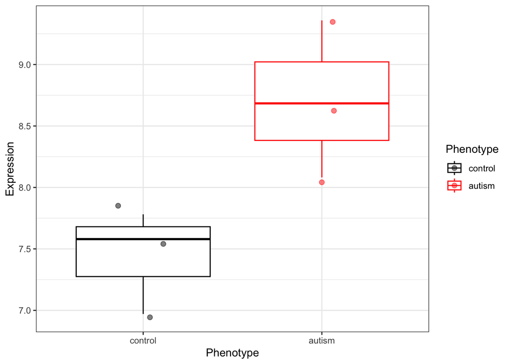

Interpret this plot in the context of the baseMean- and log2FoldChange-values in the table above.

We use adjusted p-value to decide if a gene is significantly differentially expressed or not. The default method for adjusting p-values is `"BH"` (which is short for Benjamini & Hochberg). This is the same as false discovery rate (FDR) which is what they refer to in the article. (The FDR adjusted p-value, or simply FDR, is also sometimes referred to as the q-value).

Some genes (e.g. ENSG00000000005) does not get an adjusted p-value (`NA`). This is because DESeq has decided that it cannot reliably compute significance for this gene due to low expression or outliers. Some of these genes have `NA`-values in all columns: Why do you think this is?

The table above is not very helpful. We want to know how many differentially expressed genes (DEGs) there are. And we want a nice table sorted on p-value. DESeq doesn’t give us a lot of help with this. We have to use our *Tidyverse* skills. Create a table called `res0.05` that is sorted on `padj` and only includes genes with an FDR adjusted p-value less than $0.05$.

```
              Gene baseMean log2FoldChange  lfcSE   stat    pvalue      padj
1  ENSG00000184557    490.5          4.563 0.5326  8.568 1.050e-17 1.686e-13
2  ENSG00000143546    117.9          4.217 0.5470  7.708 1.273e-14 1.022e-10
3  ENSG00000115602    185.0          5.695 0.7542  7.552 4.302e-14 2.303e-10
4  ENSG00000147571    269.3         -2.383 0.3245 -7.345 2.060e-13 7.128e-10
5  ENSG00000177464    258.9          2.831 0.3859  7.335 2.219e-13 7.128e-10
6  ENSG00000143858   1569.7         -4.285 0.5916 -7.243 4.402e-13 1.164e-09
7  ENSG00000187664   3223.4         -3.425 0.4742 -7.223 5.075e-13 1.164e-09
8  ENSG00000100285   4105.7         -3.618 0.5198 -6.960 3.414e-12 6.245e-09
9  ENSG00000102362    247.0          3.113 0.4475  6.956 3.500e-12 6.245e-09
10 ENSG00000175426   1134.1         -2.876 0.4240 -6.783 1.179e-11 1.893e-08
```

Use the DEA tables (`res` and `res0.05`) to answer the following questions:

- How many genes with expression were tested?
- What proportion of genes are DEGs?
- How many DEGs are up and how many are down in autism compared to control?
- How many DEGs do we expect to be false positives given the FDR cutoff?

### MA plot

A MA plot gives a good visual overview of the DE results. For each gene (point) the mean expression level is plotted against the log2 FC. The x-axis at log2 FC = 0 indicates that there is no change in expression. Genes highlighted in blue are significant DEGs according to our cutoff. Genes in grey are not differentially expressed.

Reproduce the MA plot below. Hint: use `scale_x_log10()` to log10-scale the x-axis.

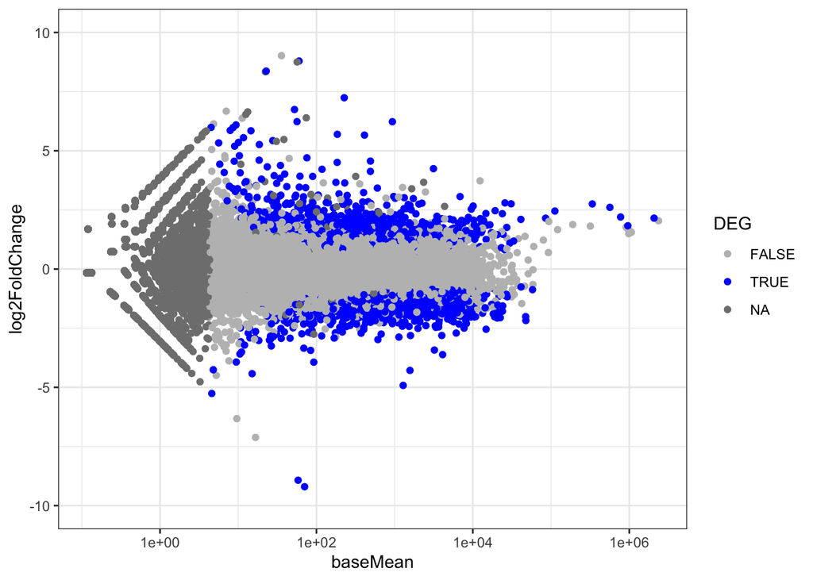

Study the plot and answer these questions:

- Why aren’t all genes with a log fold change above/below a certain level DEGs (e.g. why is the gene with the highest log fold change grey)?
- Why are there so many genes with high log fold change that are not DEGs on the left hand side of the plot?

### Vulcano plot

Another useful visualization of DEGs is the Vulcano plot.

Reproduce the Vulcano plot below and briefly explain how to read it.

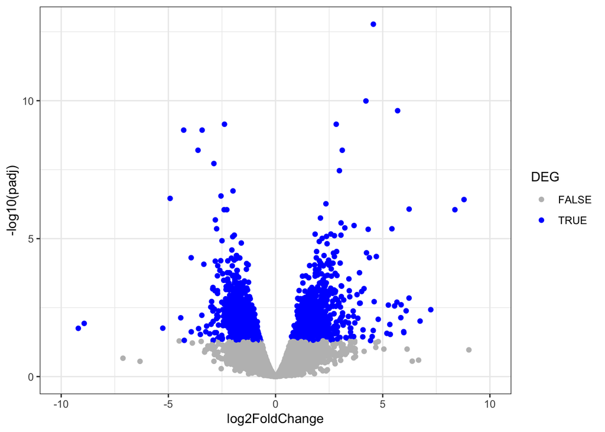

### FC cuttoff

It’s common to set a FC cutoff as well as a FDR cutoff to select DEGs. This is because genes with a low fold change are though of as having less biological relevance.

Create a new table `res0.05FC` that contains significant DEGs (FDR < 0.05) with expression levels that are either double that of the control condition or half that of the control condition.

### Save the results for later

```r
save(dds, vst, res, res0.05, res0.05FC, file = "autism_DEA.RData")
```

### GO enrichment

In the article, they did Gene Ontology enrichment of the DEGs (between autism and controls in cortex). This is what they said: “*Gene ontology enrichment analysis showed that the genes downregulated in autistic cortex were enriched for gene ontology categories related to synaptic function, whereas the upregulated genes showed enrichment for gene ontology categories implicated in immune and inflammatory response.*”

We will use the online tool [enrichr](https://maayanlab.cloud/Enrichr/) to see if we get a similar result using the RNA-Seq data. As input, enrichr needs a list of genes (file with one gene per line).

We also need to convert the names in our DEG table (from ensembl) into gene symbols before we can use the enrichr tool. Download the id conversion table *Human_ensembl_ids_to_symbols.txt* from Canvas.

Perform the following steps:

- Convert and write the gene symbols from the DEG table `res0.05FC` (filtering on both FDR and fold change) to **separate files for up- and down-regulated genes**.
- Open the [enrichr](https://maayanlab.cloud/Enrichr/) web site, paste the up-regulated gene symbols into the text box and click “Submit”. The enrichr tool has several categories to choose from, and you should select the “ontologies”-tab and then “GO Biological Process”. There you should see a list of enriched gene ontology terms. Do the results agree with what the authors of the paper found?
- Repeat the analysis with the down-regulated genes.
- Take [screen shots](https://www.take-a-screenshot.org) and include the figures from Enrichr in your R Markdown report.